# Stat 151A Lab 10

Bryan Liu

October 26, 2018

```r
library(tidyverse)
library(MASS)
library(leaps)

set.seed(245234)
```

# Statistics is made up and nothing is real

“If you torture the data long enough, it will confess.” – Ronald Coase

This example is adapted from Freedman 1983[^1].

Suppose we have 500 observations with each $x_i \in \mathbb{R}^{100}$, and $y_i \in \mathbb{R}$. We draw $x_i \sim \mathcal{N}(0, I_{100 \times 100})$ and $y_i \sim \mathcal{N}(0, 1)$. In other words, OUR DATAFRAME IS JUST RANDOM, INDEPENDENT NOISE. Literally every entry in our dataframe is independent, and most crucially, the $y$’s have no relationship to the $x$’s.

We will run a regression on this dataset, and see what we get.

```r
n <- 500 # number of observations
p <- 100 # dimension of features

# draw X
X <- matrix(rnorm(n * p), nrow = n)

# draw y
y <- rnorm(n)

# create dataframe
data_noise <- cbind(y, X)
data_noise <- as.data.frame(data_noise)

# fit regression
full_model <- lm(y ~ ., data_noise)
full_model_summary <- summary(full_model)

full_model_summary
```

```
##
## Call:
## lm(formula = y ~ ., data = data_noise)
##
## Residuals:
##     Min      1Q  Median      3Q     Max
## -3.1579 -0.6383  0.0321  0.6331  3.6201
##
## Coefficients:
##               Estimate Std. Error t value Pr(>|t|)
## (Intercept) -0.0035828  0.0537588  -0.067   0.9469
## V2          -0.0608978  0.0537750  -1.132   0.2581
## V3           0.0171146  0.0517826   0.331   0.7412
## V4           0.0108009  0.0540058   0.200   0.8416
## V5          -0.0358071  0.0501036  -0.715   0.4752
## V6          -0.0059811  0.0526894  -0.114   0.9097
## V7           0.0996295  0.0522914   1.905   0.0575 .
## V8          -0.0464582  0.0564207  -0.823   0.4108
## V9          -0.0065619  0.0561214  -0.117   0.9070
## V10         -0.0250189  0.0504068  -0.496   0.6199
## V11          0.0393108  0.0520852   0.755   0.4508
## V12         -0.0599619  0.0528234  -1.135   0.2570
## V13         -0.1201676  0.0527884  -2.276   0.0234 *
## V14         -0.0281686  0.0523316  -0.538   0.5907
## V15          0.0573505  0.0532227   1.078   0.2819
## V16          0.0108351  0.0523714   0.207   0.8362
## V17          0.1015846  0.0531083   1.913   0.0565 .
## V18          0.0580223  0.0512501   1.132   0.2583
## V19         -0.0231464  0.0498973  -0.464   0.6430
## V20          0.1128919  0.0524359   2.153   0.0319 *
## V21          0.0411797  0.0530685   0.776   0.4382
## V22         -0.0327406  0.0540380  -0.606   0.5449
## V23          0.0174862  0.0499785   0.350   0.7266
## V24          0.0414153  0.0538474   0.769   0.4423
## V25          0.0321394  0.0553631   0.581   0.5619
## V26          0.0004944  0.0512461   0.010   0.9923
## V27         -0.0333721  0.0555629  -0.601   0.5484
## V28         -0.0649953  0.0512899  -1.267   0.2058
## V29         -0.0518413  0.0542992  -0.955   0.3403
## V30         -0.0741989  0.0531593  -1.396   0.1636
```

[output cut: 62 more lines]

```
## V93          0.0675623  0.0523360   1.291   0.1975
## V94          0.0278903  0.0527298   0.529   0.5971
## V95          0.0945157  0.0505180   1.871   0.0621 .
## V96         -0.0398634  0.0534016  -0.746   0.4558
## V97          0.0125771  0.0522202   0.241   0.8098
## V98         -0.0302987  0.0498370  -0.608   0.5436
## V99          0.0188339  0.0526981   0.357   0.7210
## V100        -0.0443306  0.0518158  -0.856   0.3928
## V101         0.0592238  0.0514225   1.152   0.2501
## ---
## Signif. codes:  0 '***' 0.001 '**' 0.01 '*' 0.05 '.' 0.1 ' ' 1
##
## Residual standard error: 1.047 on 399 degrees of freedom
## Multiple R-squared:  0.1883, Adjusted R-squared:  -0.01511
## F-statistic: 0.9257 on 100 and 399 DF,  p-value: 0.6743
```

What are the true values for $\beta_0, ..., \beta_{100}$ in our data generating process?

What doe the $F$ statistic say? Is this consistent with our data generating process?

Lets see how many $\hat\beta_i$’s were significantly different from 0.

```r
# get p-values
p_vals <- coef(full_model_summary)[, 'Pr(>|t|)']

# print how many were less than 0.05
print(sum(p_vals < 0.05))
```

```
## [1] 3
```

Is this surprising?

Ok, so now lets do model selection by including only the coefficients with the top 3 p-values in the model.

```r
# pick out top three coefficients
which_top3 <- order(p_vals)[1:3]
print(p_vals[which_top3])
```

```
##        V13        V20        V86
## 0.02335104 0.03192140 0.03456819
```

```r
# and only run the regression on the coefficients with the top 3 p-values
data_noise_selected <- data_noise[,  c('y', names(p_vals[which_top3]))]
summary(lm(y ~ ., data = data_noise_selected))
```

```
##
## Call:
## lm(formula = y ~ ., data = data_noise_selected)
##
## Residuals:
##     Min      1Q  Median      3Q     Max
## -3.3479 -0.6939  0.0276  0.6608  3.8411
##
## Coefficients:
##              Estimate Std. Error t value Pr(>|t|)
## (Intercept) -0.005595   0.046109  -0.121   0.9035
## V13         -0.087358   0.046024  -1.898   0.0583 .
## V20          0.086438   0.044405   1.947   0.0522 .
## V86          0.119127   0.046180   2.580   0.0102 *
## ---
## Signif. codes:  0 '***' 0.001 '**' 0.01 '*' 0.05 '.' 0.1 ' ' 1
##
## Residual standard error: 1.027 on 496 degrees of freedom
## Multiple R-squared:  0.0288, Adjusted R-squared:  0.02293
## F-statistic: 4.903 on 3 and 496 DF,  p-value: 0.002287
```

What does the F-statistic say now???

Fine, lets try something fancier than just picking coefficients with large p-values. In class we talked about doing stepwise search. Lets do a backwards search, with AIC as our criterion. R has a nice function for this. It’ll suffice for our demonstration.

```r
# this line takes a minute
aic_selected_model <- stepAIC(full_model, direction = 'backward',
                              trace = FALSE)
# print the result
summary(aic_selected_model)
```

```
##
## Call:
## lm(formula = y ~ V2 + V7 + V12 + V13 + V17 + V20 + V30 + V31 +
##     V47 + V50 + V75 + V80 + V86 + V90 + V91 + V95, data = data_noise)
##
## Residuals:
##     Min      1Q  Median      3Q     Max
## -3.6676 -0.6467 -0.0311  0.6336  3.8148
##
## Coefficients:
##             Estimate Std. Error t value Pr(>|t|)
## (Intercept) -0.01233    0.04524  -0.272  0.78540
## V2          -0.07388    0.04597  -1.607  0.10870
## V7           0.10300    0.04613   2.233  0.02601 *
## V12         -0.07006    0.04624  -1.515  0.13040
## V13         -0.10478    0.04522  -2.317  0.02093 *
## V17          0.12316    0.04475   2.752  0.00615 **
## V20          0.10389    0.04371   2.377  0.01786 *
## V30         -0.06567    0.04558  -1.441  0.15026
## V31          0.09213    0.04748   1.940  0.05292 .
## V47          0.09878    0.04619   2.139  0.03295 *
## V50          0.06257    0.04351   1.438  0.15110
## V75          0.07053    0.04444   1.587  0.11313
## V80          0.06782    0.04328   1.567  0.11777
## V86          0.10823    0.04529   2.390  0.01725 *
## V90          0.07238    0.04733   1.529  0.12688
## V91          0.09283    0.04868   1.907  0.05711 .
## V95          0.08238    0.04457   1.848  0.06515 .
## ---
## Signif. codes:  0 '***' 0.001 '**' 0.01 '*' 0.05 '.' 0.1 ' ' 1
##
## Residual standard error: 0.9926 on 483 degrees of freedom
## Multiple R-squared:  0.1168, Adjusted R-squared:  0.08751
## F-statistic: 3.991 on 16 and 483 DF,  p-value: 3.789e-07
```

Observations about $F$ and/or $T$ statistics?

# Anyyyyyway …

Lets pretend we did not see that and continue with this lab.

Note that that was a caution about *inference*. We can always use linear regression and whatever selection techniques we choose, if we are only aiming for *prediction*.

## (Information) Criteria

In our model, we have a total of $p$ explainatory variables. Suppose we decide only to include a subset of $p' \leq p$ variables in our model. **How many possible models with $p'$ variables are there?**

Suppose we can search through all the models with $p'$ explainatory variables. We need some criterion to determine which is best.

A quantity that shows up in many of the information criteria discussed in class is the log-likelihood of the linear model, with normal errors, at the estimates $\hat\beta$ and $\hat\sigma^2$.

Suppose $y \sim \mathcal{N}(X\beta, \sigma^2 I_{n\times n})$. Then the log-likelihood is given by
$$\begin{align}
\log p(y ; \beta, \sigma^2)
= - \frac{n}{2} \log(2 \pi \sigma^2) - \frac{\|y - X\beta\|^2}{2 \sigma^2}
\end{align}$$

**Check that $\hat\beta_{MLE} = (X^TX)^{-1}X^Ty$, and $\hat\sigma^2_{MLE} = RSS / n$ is the MLE**, that is, these formulae for $\hat\beta_{MLE}$ and $\hat\sigma_{MLE}^2$ maximize the log-likelihood. (Note that $\hat\beta_{MLE}$ is our usual formula obtained by solving the least squares formula; however, $\hat\sigma^2_{MLE} = RSS / n$ is not the familiar unbiased estimate for the variance. )

So now let us list the criteria that we might use to select which model is best. Let $m$ denote the model, with $p(m)$ being the number of explainatory variables in the model:

- Adjusted $R^2$:

$$\begin{align}
(\text{Adj. $R^2$})(m) := 1 - \frac{\text{RSS}(m) / (n - p(m) - 1)}{\text{TSS} / (n - 1)}
\end{align}$$

- AIC:

$$\begin{align}
\text{AIC}(m)
&:= - 2 \log(\text{max value of likelihood in $m$}) + 2(\text{number of parameters in $m$})
\\
&= n \log(2 \pi e) + n \log \left(\frac{\text{RSS(m)}}{n}\right) + 2(p(m)+1)
\end{align}$$

We compare AIC$(m)$ for all models $m$, so we can drop the constant $n\log(2\pi e)$ since it does not depend on $m$. Some implementations have different terms in computing their AIC . But they should differ by only an additive constant.

- BIC:

$$\begin{align}
\text{BIC}(m)
&:= - 2 \log(\text{max value of likelihood in $m$}) + \log(n) \cdot (\text{number of parameters in $m$})
\\
&= n \log(2 \pi e) + n \log \left(\frac{\text{RSS(m)}}{n}\right) + \log(n) \cdot (p(m)+1).
\end{align}$$

We can again drop the constant term. How does BIC penalize complexity $p(m)$ compared to AIC?

- Mallows $C_p$: Suppose that the data did come from the model $y = X\beta + \epsilon$, $\epsilon \sim \mathcal{N}(0, I_{n\times n})$. The idea behind the Mallows $C_p$ score is that the $C_p$ score is a proxy of the quantity

$$\begin{align}
E\|H(m) Y - X\beta\|^2
\end{align}$$
We would like to choose $m$ to minimize this expectation. In class, we computed this to be
$$\begin{align}
E\|H(m) Y - X\beta\|^2= \sigma^2(p(m) + 1) + \beta^T X^T(I - H(m))X\beta
\end{align}$$

**Show that this equals $\sigma^2(p(M) + 1)$ when $M$ is the full model**.

We claim that

$$\begin{align}
RSS(m) - \sigma^2(n - 2 - 2p(m))
\end{align}$$

is an unbiased estimate of the expectation. **Show.**

We divide through by $\sigma^2$, and replace $\sigma^2$ with $\hat\sigma^2$. This results in Mallow’s $C_p$ score:

$$\begin{align}
C_p(m) := \frac{RSS(m)}{\hat\sigma^2} - (n - 2 - 2p(m))
\end{align}$$

So now, to do model selection, we pick our favorite criteria, and optimize the criterion in two stages:

1. For each subset size $p' = 0, ..., p$, find the model with exactly $p'$ explainatory variables with the smallest RSS (for these criteria, why does it suffice to just minimize RSS in step 1?).
2. For these $p + 1$ models, pick the one with the smallest criterion (AIC/BIC/etc) value.

## Supernova dataset

We consider a dataset from Brad Efron and Trevor Hastie’s book, *Computer Age Statistical Inference*. The data measures the brightness of 39 supernova, as a function of $p = 10$ spectral energies. Note that the brightnesses (the $y$) have been centered to have zero mean, and the $x$’s are scaled to have zero mean and unit variance.

```r
# load data
supernova <- read.table("http://web.stanford.edu/~hastie/CASI_files/DATA/supernova.txt", header=TRUE)

head(supernova)
```

```
##         E1     E2     E3     E4     E5     E6     E7     E8     E9    E10
## SN1 -0.839 -0.927  0.320  0.176 -0.676 -1.272  0.342 -0.427 -0.016 -0.298
## SN2 -1.892 -0.455  2.407  0.766 -0.944 -1.527  0.088  0.261  0.185 -0.537
## SN3  0.264 -0.803  1.141 -0.863  0.685 -0.354 -1.038 -1.098 -1.319 -1.695
## SN4 -0.083  1.023 -0.206 -1.115 -0.863  0.715  0.616  0.564  0.615 -0.488
## SN5  0.411 -0.807 -0.129  1.315 -0.647  0.299 -0.822 -1.534 -1.486 -1.087
## SN6  0.000 -1.917  1.832  1.380 -0.782 -1.914 -1.630  0.609  1.451  1.619
##     Magnitude
## SN1    -0.543
## SN2     2.124
## SN3    -0.217
## SN4     0.946
## SN5    -3.746
## SN6    -2.118
```

The goal is to use a regression model to predict supernova brightness from the spectral energies. Lets hold out 10 of the 39 observations as a test set.

```r
# Do train/test split
set.seed(4534534)
sample_10 <- sample(dim(supernova)[1], 10)

supernova_train <- supernova[-sample_10, ]
supernova_test <- supernova[sample_10, ]
```

```r
# fit on training set
lm_fit <- lm(Magnitude ~ . -1, data = supernova_train)

# examine predictive accuracy on the training set
predict_train_data <- predict(lm_fit, data = supernova_train)
R2_train <- cor(predict_train_data, supernova_train[, 'Magnitude'])**2
cat('R^2 on training data: ', R2_train)
```

```
## R^2 on training data:  0.8364178
```

Not bad, right?

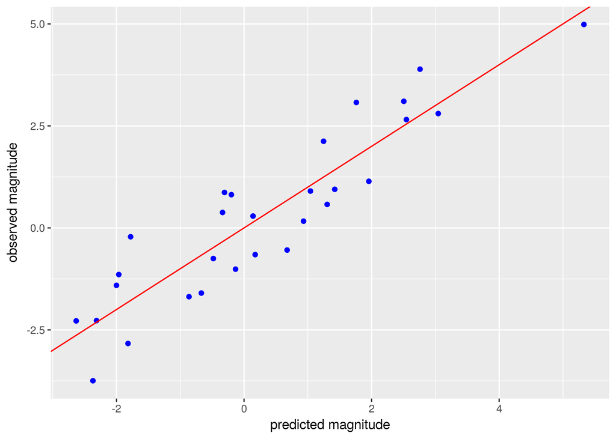

```r
# plot observed vs predicted values in the training set
ggplot() +
  geom_point(aes(x = predict_train_data, y = supernova_train[, 'Magnitude']),
             color = 'blue') +
  ylab('observed magnitude') + xlab('predicted magnitude') +
  geom_abline(slope = 1, color = 'red')
```

```r
pred_test_data <- predict(lm_fit, newdata = supernova_test)
R2_test <- cor(pred_test_data, supernova_test[, 'Magnitude'])**2
# get R^2 of test data
cat('R^2 on test data: ', R2_test)
```

```
## R^2 on test data:  0.5770651
```

What happened?

Let us do variable selection and search for which of the 10 spectal energies are actually important for prediction. We will use the `leaps` package in R, and use Mallow’s Cp score.

```r
leaps_output <- leaps(y = supernova$Magnitude, x = supernova[, 1:10],
                      method = 'Cp', nbest = 1, int = FALSE)

print(leaps_output)
```

```
## $which
##        1     2     3     4     5     6    7     8     9     A
## 1  FALSE FALSE FALSE FALSE FALSE FALSE TRUE FALSE FALSE FALSE
## 2  FALSE FALSE FALSE FALSE FALSE FALSE TRUE FALSE  TRUE FALSE
## 3  FALSE FALSE FALSE FALSE FALSE FALSE TRUE FALSE  TRUE  TRUE
## 4   TRUE FALSE FALSE FALSE FALSE FALSE TRUE FALSE  TRUE  TRUE
## 5  FALSE  TRUE FALSE  TRUE FALSE  TRUE TRUE FALSE  TRUE FALSE
## 6   TRUE  TRUE FALSE  TRUE FALSE  TRUE TRUE FALSE  TRUE FALSE
## 7   TRUE  TRUE FALSE  TRUE  TRUE  TRUE TRUE FALSE  TRUE FALSE
## 8   TRUE  TRUE  TRUE  TRUE  TRUE  TRUE TRUE FALSE  TRUE FALSE
## 9   TRUE  TRUE  TRUE  TRUE  TRUE  TRUE TRUE  TRUE  TRUE FALSE
## 10  TRUE  TRUE  TRUE  TRUE  TRUE  TRUE TRUE  TRUE  TRUE  TRUE
##
## $label
##  [1] "1" "2" "3" "4" "5" "6" "7" "8" "9" "A"
##
## $size
##  [1]  1  2  3  4  5  6  7  8  9 10
##
## $Cp
##  [1] 12.60443160  2.07836968 -0.74682947 -0.07663168  1.21410340
##  [6]  2.18354535  4.03995800  6.00444676  8.00125380 10.00000000
```

Using the selected explainatory variables, lets fit again using the training data.

```r
# Probably an easier way to do this.
# was too lazy to dig into leaps documentation
# so I'll do it myself
# This function returns a dataframe with only the X selected columns (and the y)
get_selected_x_from_leaps <- function(leaps_ouput, supernova){
  # get the columns that minimizes Cp
  which_model <- which.min(leaps_output$Cp)
  which_X_columns <- leaps_output$which[which_model, ]

  # create new dataset with only selected columns
  supernova_selected_x <- cbind(supernova[, c(which_X_columns)], supernova[, 11])
  names(supernova_selected_x)[length(names(supernova_selected_x))] <- 'Magnitude'

  return(supernova_selected_x)
}

# get selected fit
selected_supernova_train <- get_selected_x_from_leaps(leaps_ouput, supernova_train)
lm_fit_selected <- lm(Magnitude ~ . -1, data = selected_supernova_train)

# check R^2 on train data
pred_train_data <- predict(lm_fit_selected, newdata = selected_supernova_train)
R2_train <- cor(pred_train_data, selected_supernova_train[, 'Magnitude'])**2
cat('R^2 on training data: ', R2_train)
```

```
## R^2 on training data:  0.8081569
```

The fit on the test data with selected columns?

```r
# check R^2 on test data
selected_supernova_test <- get_selected_x_from_leaps(leaps_ouput, supernova_test)
pred_test_data <- predict(lm_fit_selected, newdata = selected_supernova_test)
R2_test <- cor(pred_test_data, selected_supernova_test[, 'Magnitude'])**2
cat('R^2 on test data: ', R2_test)
```

```
## R^2 on test data:  0.6743645
```

[^1]: Freedman, D. A. (1983) “A note on screening regression equations.” The American Statistician, 37, 152–155